# Are Pokemon Born Equal? Analisys Using Multidimensional Scaling and Clustering

Michał Szałański

10 marca 2019

# Preparing data

## Libraries

```r
library(dplyr)
library(tidyr)
library(ggplot2)
library(gridExtra)
library(corrplot)
library(labdsv)
library(smacof)
library(psych)
library(pca3d)
library(NbClust)
library(ClusterR)
library(wesanderson)
library(factoextra)
library(clustertend)
library(knitr)
options(scipen=999)

# Define nice colors
cYellow = '#FADA5E'
cBlue = '#378CC7'
```

## Loading the data from a csv.

The source is a fantastic [Kaggle](https://www.kaggle.com/abcsds/pokemon) dataset containing the statistick for every pokemon released.

```r
pokemon <- read.csv('data/Pokemon.csv')
pokemon <- rename(pokemon, 'Special.Attack' = 'Sp..Atk', 'Special.Defense' = 'Sp..Def')
```

## First look at the data

```r
a <- pokemon %>% filter(pokemon$Name == 'Pikachu')
kable(a)
```

| X. | Name | Type.1 | Type.2 | Total | HP | Attack | Defense | Special.Attack | Special.Defense | Speed | Generation | Legendary |
| --- | --- | --- | --- | --- | --- | --- | --- | --- | --- | --- | --- | --- |
| 25 | Pikachu | Electric |  | 320 | 35 | 55 | 40 | 50 | 50 | 90 | 1 | False |

```r
dim(pokemon)
```

```
[1] 800  13
```

```r
str(pokemon)
```

```
'data.frame':   800 obs. of  13 variables:
 $ X.             : int  1 2 3 3 4 5 6 6 6 7 ...
 $ Name           : Factor w/ 800 levels "Abomasnow","AbomasnowMega Abomasnow",..: 81 330 746 747 103 104 100 101 102 666 ...
 $ Type.1         : Factor w/ 18 levels "Bug","Dark","Dragon",..: 10 10 10 10 7 7 7 7 7 18 ...
 $ Type.2         : Factor w/ 19 levels "","Bug","Dark",..: 15 15 15 15 1 1 9 4 9 1 ...
 $ Total          : int  318 405 525 625 309 405 534 634 634 314 ...
 $ HP             : int  45 60 80 80 39 58 78 78 78 44 ...
 $ Attack         : int  49 62 82 100 52 64 84 130 104 48 ...
 $ Defense        : int  49 63 83 123 43 58 78 111 78 65 ...
 $ Special.Attack : int  65 80 100 122 60 80 109 130 159 50 ...
 $ Special.Defense: int  65 80 100 120 50 65 85 85 115 64 ...
 $ Speed          : int  45 60 80 80 65 80 100 100 100 43 ...
 $ Generation     : int  1 1 1 1 1 1 1 1 1 1 ...
 $ Legendary      : Factor w/ 2 levels "False","True": 1 1 1 1 1 1 1 1 1 1 ...
```

```r
a <- summary(pokemon)[,c(1:4,12,13)]
b <- summary(pokemon)[,c(5:11)]
kable(a)
```

|  | X. | Name | Type.1 | Type.2 | Generation | Legendary |
| --- | --- | --- | --- | --- | --- | --- |
|  | Min. : 1.0 | Abomasnow : 1 | Water :112 | :386 | Min. :1.000 | False:735 |
|  | 1st Qu.:184.8 | AbomasnowMega Abomasnow: 1 | Normal : 98 | Flying : 97 | 1st Qu.:2.000 | True : 65 |
|  | Median :364.5 | Abra : 1 | Grass : 70 | Ground : 35 | Median :3.000 | NA |
|  | Mean :362.8 | Absol : 1 | Bug : 69 | Poison : 34 | Mean :3.324 | NA |
|  | 3rd Qu.:539.2 | AbsolMega Absol : 1 | Psychic: 57 | Psychic : 33 | 3rd Qu.:5.000 | NA |
|  | Max. :721.0 | Accelgor : 1 | Fire : 52 | Fighting: 26 | Max. :6.000 | NA |
|  | NA | (Other) :794 | (Other):342 | (Other) :189 | NA | NA |

```r
kable(b)
```

|  | Total | HP | Attack | Defense | Special.Attack | Special.Defense | Speed |
| --- | --- | --- | --- | --- | --- | --- | --- |
|  | Min. :180.0 | Min. : 1.00 | Min. : 5 | Min. : 5.00 | Min. : 10.00 | Min. : 20.0 | Min. : 5.00 |
|  | 1st Qu.:330.0 | 1st Qu.: 50.00 | 1st Qu.: 55 | 1st Qu.: 50.00 | 1st Qu.: 49.75 | 1st Qu.: 50.0 | 1st Qu.: 45.00 |
|  | Median :450.0 | Median : 65.00 | Median : 75 | Median : 70.00 | Median : 65.00 | Median : 70.0 | Median : 65.00 |
|  | Mean :435.1 | Mean : 69.26 | Mean : 79 | Mean : 73.84 | Mean : 72.82 | Mean : 71.9 | Mean : 68.28 |
|  | 3rd Qu.:515.0 | 3rd Qu.: 80.00 | 3rd Qu.:100 | 3rd Qu.: 90.00 | 3rd Qu.: 95.00 | 3rd Qu.: 90.0 | 3rd Qu.: 90.00 |
|  | Max. :780.0 | Max. :255.00 | Max. :190 | Max. :230.00 | Max. :194.00 | Max. :230.0 | Max. :180.00 |
|  | NA | NA | NA | NA | NA | NA | NA |

The dataset has a nice distribution of variables, 2 categorical, 1 binary and 8 interval. The X variable is a pokemon Id. Note that it is not unique, because later *generations* added new *evolutions* for existing pokemon.  
**Type 1** designates the primary type of the pokemon - it influences it’s strengts and weekneses (e.g. fire pokemon are weak against water pokemon) and it’s overall design. Some pokemon also have a second type.  
**Generation** is the number of generation this pokemon it’s from. First generation originated in 1996, and the 6th one in 2013. This dataset is slightly old, as it lack the 7 generation from 2016.  
Next are the statisticks for each pokemon.The **Total** vairable is a simple sum of all statistics. **HP** stands for Hit Points, the pokemon *health*. **Attack** signifies how much damage can it do, and it’s compared to the **defense** of the enemy’s pokemon. **Special attack** is simmilar to normal attack, but it’s compared to the **Special Defense**. **Speed** indicates which pokemon attacks first in a given round. Aside from these basic stats, each pokemon has it’s *moves*, *abilities* and other variables not included in this dataset. That being said, the basic statline and it’s distribution has a great impact on how powerful a given pokemon is.

## Subsetting the dataset

```r
# All stats
poke <- pokemon[, c(5:11)]

# All stats, legendary
poke <- pokemon %>% filter(Legendary == 'True')
poke <- poke[, c(6:11)]
poke2 <- pokemon %>% filter(Legendary == 'True')

# Stats without the Total
poke <- pokemon[, c(6:11)]
```

For futher analisys, there are 3 coiches of variables. First is the one including all statistics of a given pokemon - Total, HP, Attack, Defense, Special Attack, Special Defense and Speed. Generations is ignored, since it is a nominal variable.

Second choise are only the Legendary Pokemon - a small (65) subset of all pokemon, containign the rarest and most powerful pokemon.

Third choise it again all pokemon, but withous the Total statistic, since it is produced but all other statistics already included.

## Visual analisys

We can take a look at the overall distirbutions by plotting the scatter plots for all variables.

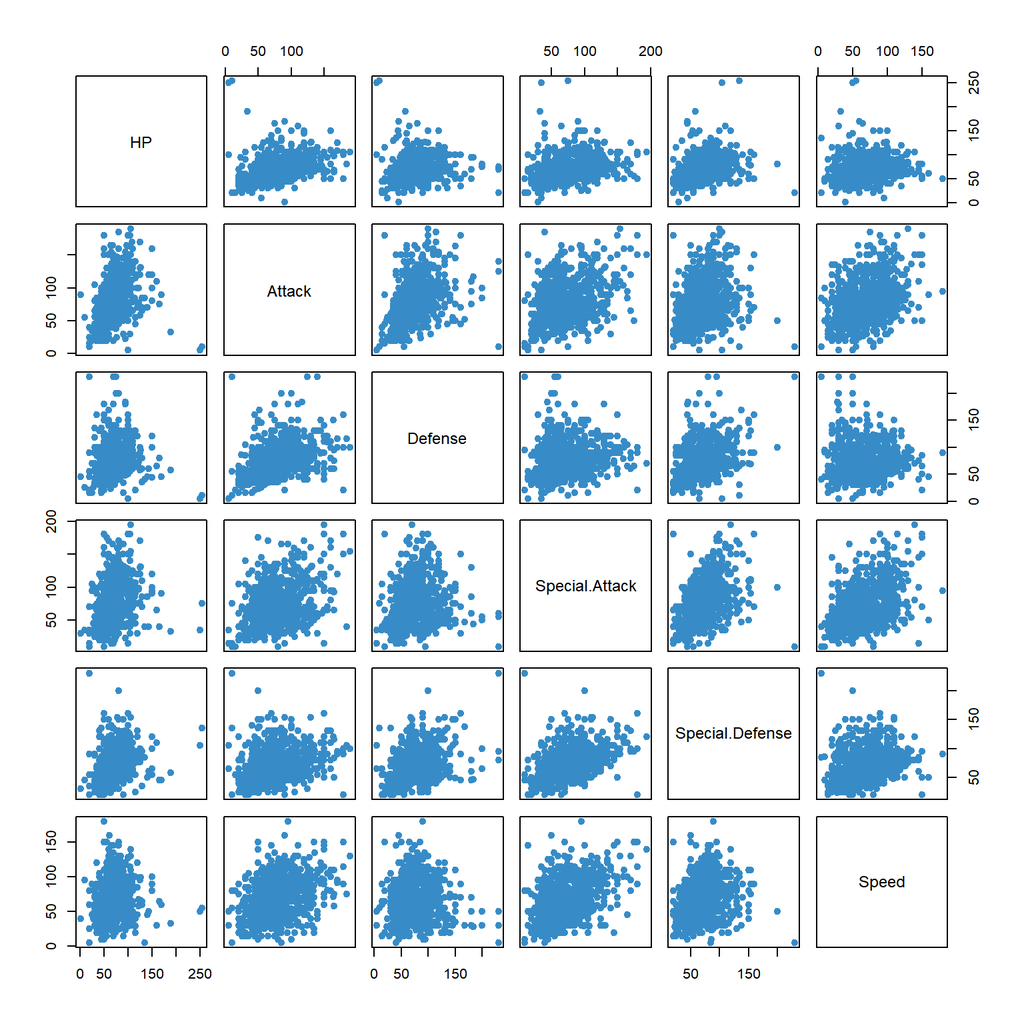

```r
plot(poke, col = cBlue, pch = 19)
```

Now, we can take a closer look at the distributions of some of the variables.

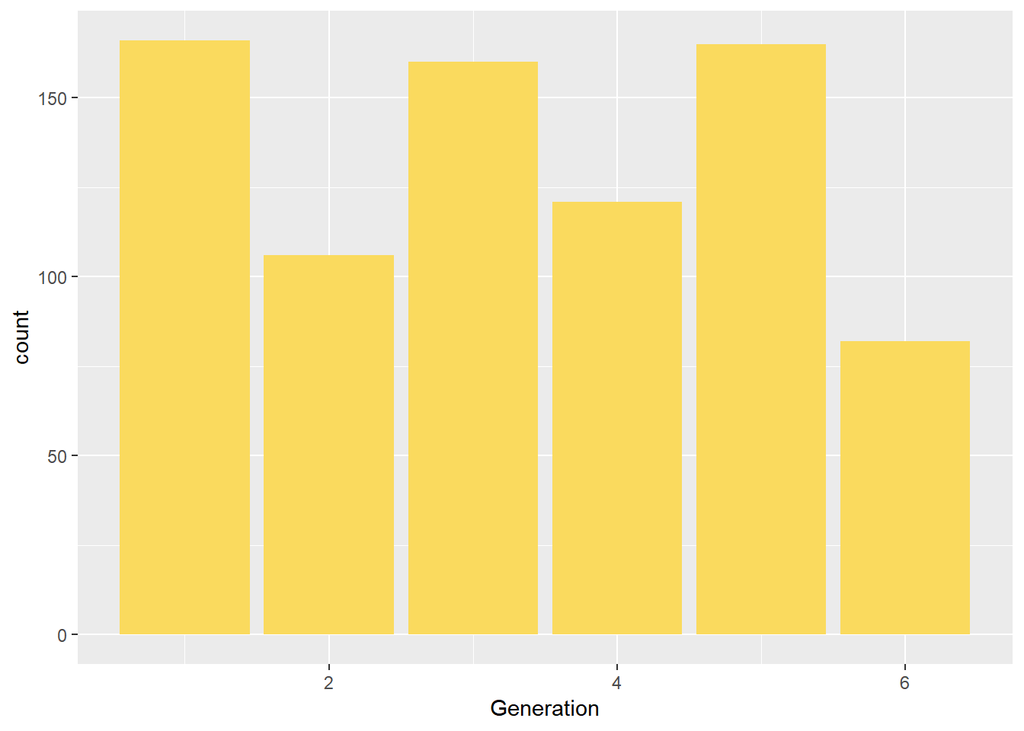

```r
ggplot(pokemon) + geom_bar(aes(x = Generation), fill = cYellow)
```

The number of pokemon per generation seems to follow a “tick-tok” distribution - each even generation has a significanly lower number of new pokemon.

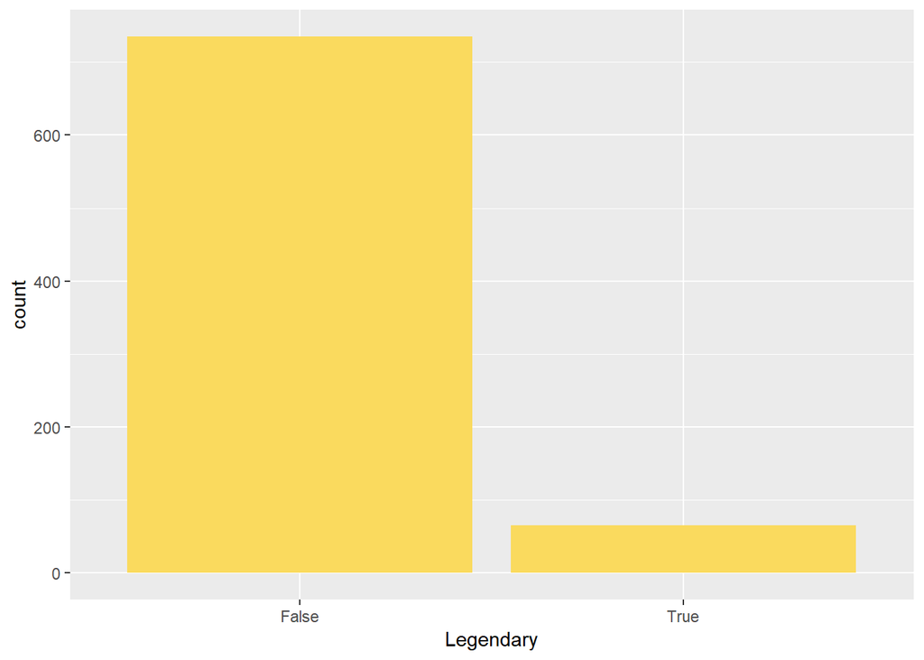

```r
ggplot(pokemon) + geom_bar(aes(x = Legendary), fill = cYellow)
```

There is a large difference beetwen the number of legendary pokemon (65) and normal ones (735)

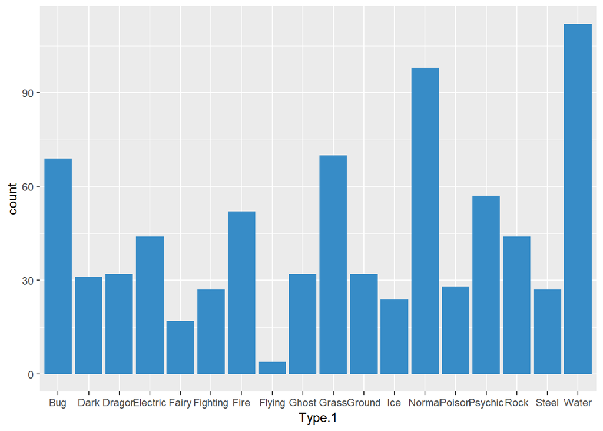

```r
ggplot(pokemon) + geom_bar(aes(x = Type.1), fill = cBlue)
```

The number of pokemon in each cattegory in not distibutet evenly. There are a lot more of the *water*, *normal* and *bug* types of pokemons. These might be a design decision, since a lot of the time in-game take place in forrests and simmilar locations. Also notable is the *flying* type - almost no pokemon has it as it’s first type.

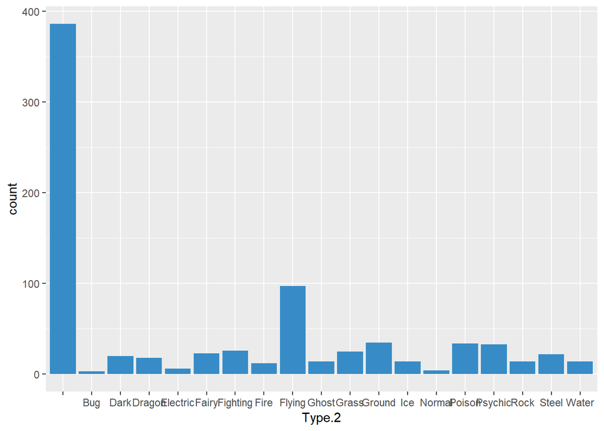

```r
ggplot(pokemon) + geom_bar(aes(x = Type.2), fill = cBlue)
```

Most pokemon don’t have a second type - but when they do, it’s typically *flying*.

We can take a look how is the Total variable distributed. It gives a good estimation on how powerful a certain pokemon can be.

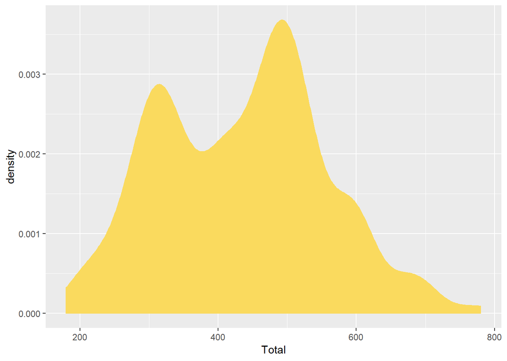

```r
ggplot(pokemon) + geom_density(aes(x = Total), fill = cYellow, colour = cYellow)
```

The distribution has two strong peaks - one at around 300, and the other at 500. These is because pokemon has a machanism of *evolution*. Many pokemon (but not all) have at least two forms. One that is weaker (e.g. a bug) and can be encountered earlier in the game, and second (e.g. a butterfly) that is a result of a *evolution* that a pokemon undergoes when it reaches a certain level of expirience. To give a sense of progress, the evolved formes are typically much stronger.

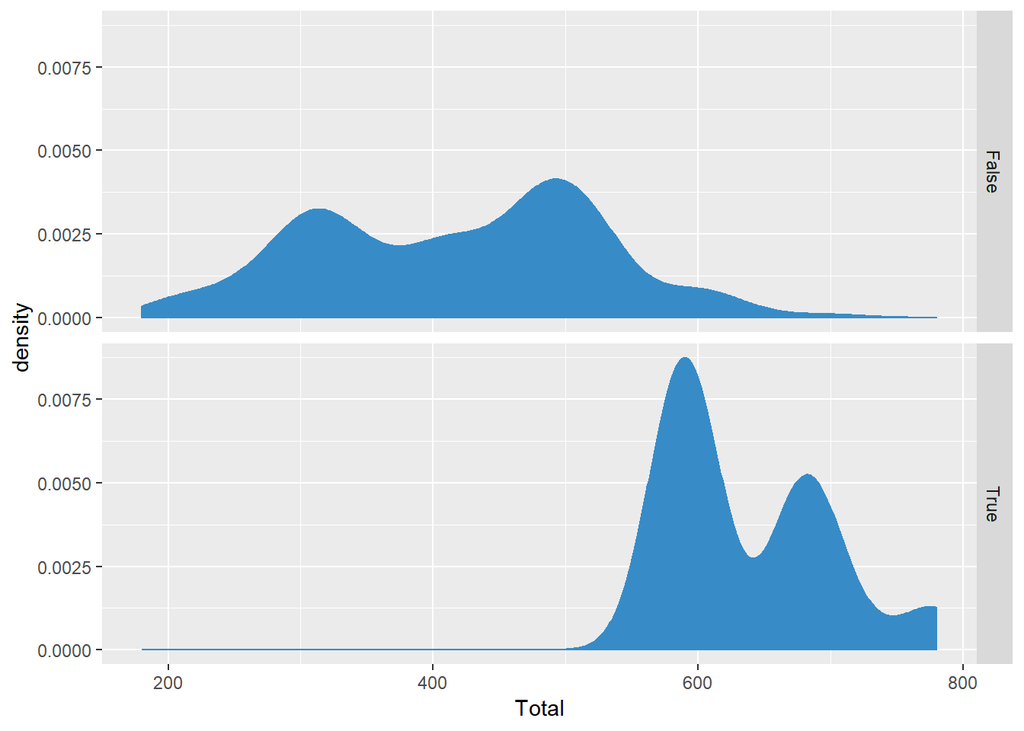

```r
ggplot(pokemon) + geom_density(aes(x = Total), fill = cBlue, colour = cBlue) + facet_grid(Legendary ~ .)
```

When comparing the Total beetwen Legendary and non-legendary pokemon, it is claer that most high spots are occupied by the legendary pokemon. They do seem to also follow ths interesting two-peak distribution, even though almost none of the evolve.

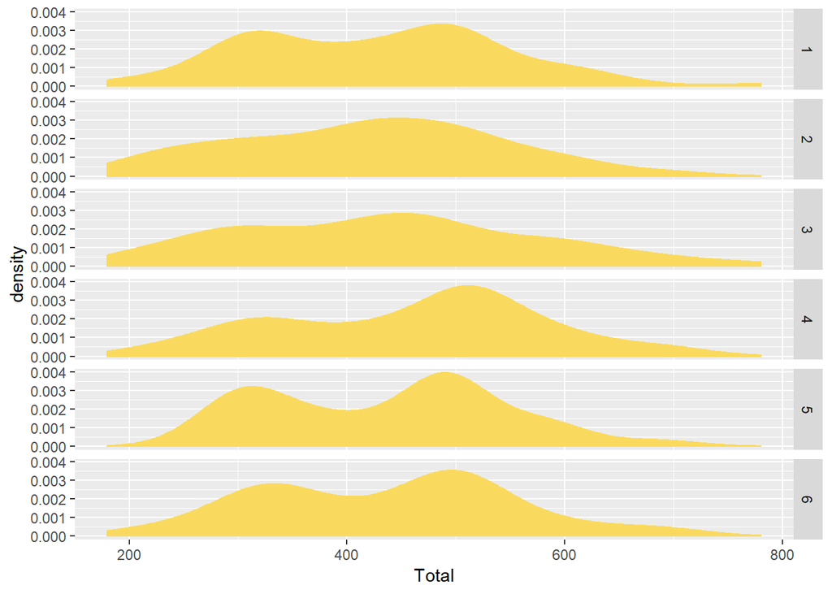

```r
ggplot(pokemon) + geom_density(aes(x = Total), fill = cYellow, colour = cYellow) + facet_grid(Generation ~ .)
```

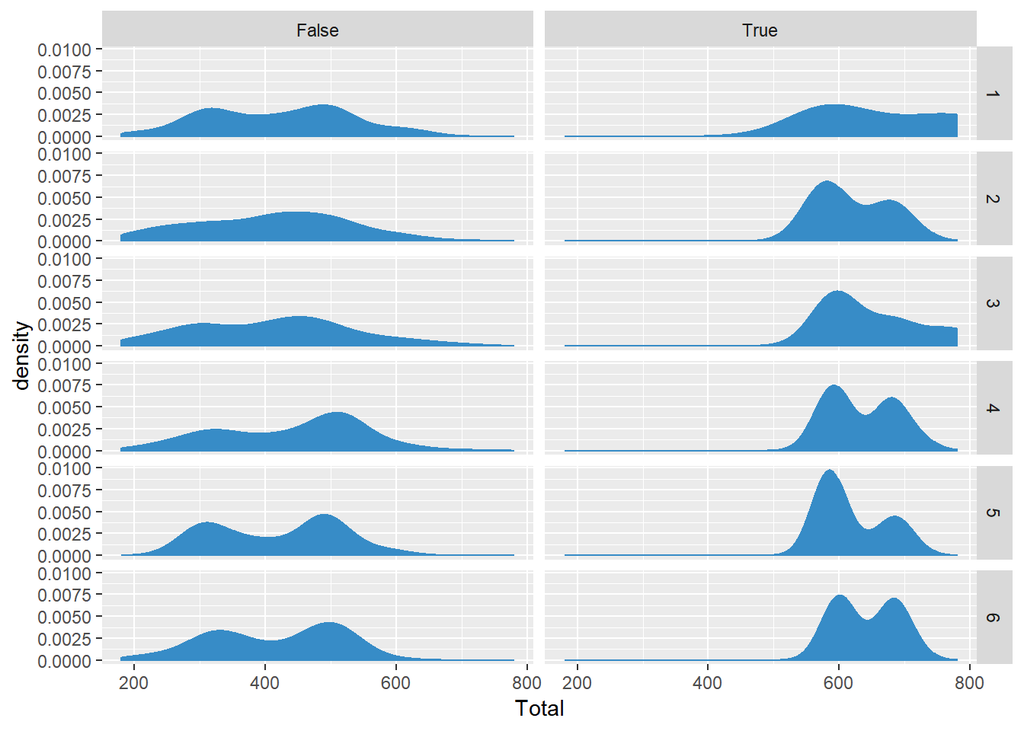

```r
ggplot(pokemon) + geom_density(aes(x = Total), fill = cBlue, colour = cBlue) + facet_grid(Generation ~ Legendary)
```

Comparing Total over generations and legendary vs non-legendary pokemon doesn’t bring new insights - the distributions seems to be quite consistent.

We can take a look how are the other variables distributed.

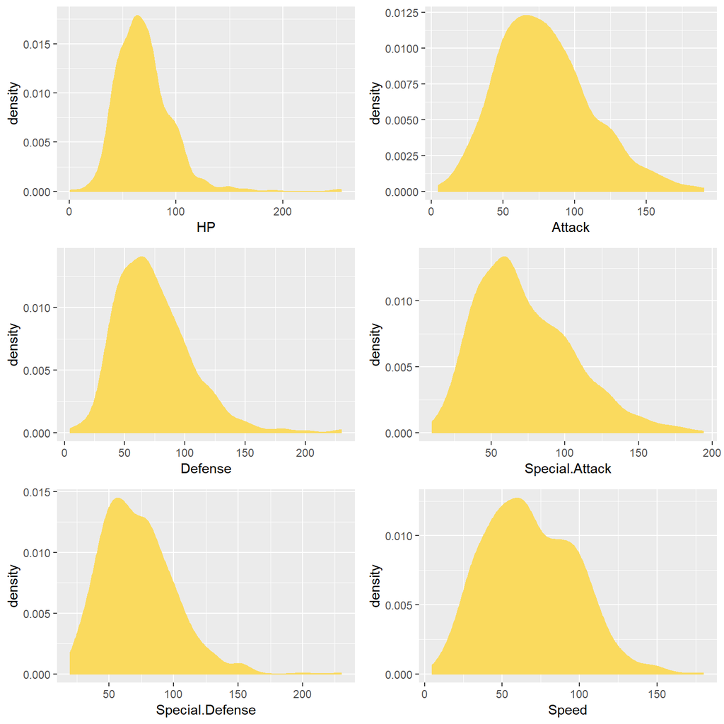

```r
p1 <- ggplot(pokemon) + geom_density(aes(x = HP), fill = cYellow, colour = cYellow)
p2 <- ggplot(pokemon) + geom_density(aes(x = Attack), fill = cYellow, colour = cYellow)
p3 <- ggplot(pokemon) + geom_density(aes(x = Defense), fill = cYellow, colour = cYellow)
p4 <- ggplot(pokemon) + geom_density(aes(x = Special.Attack), fill = cYellow, colour = cYellow)
p5 <- ggplot(pokemon) + geom_density(aes(x = Special.Defense), fill = cYellow, colour = cYellow)
p6 <- ggplot(pokemon) + geom_density(aes(x = Speed), fill = cYellow, colour = cYellow)
grid.arrange(p1, p2, p3, p4, p5, p6, nrow = 3)
```

## Correlation plot

```r
pokemonCorrelation <- cor(pokemon[, c(6:11)], method="pearson")
print(pokemonCorrelation, digits=2)
```

```
                  HP Attack Defense Special.Attack Special.Defense Speed
HP              1.00   0.42   0.240           0.36            0.38 0.176
Attack          0.42   1.00   0.439           0.40            0.26 0.381
Defense         0.24   0.44   1.000           0.22            0.51 0.015
Special.Attack  0.36   0.40   0.224           1.00            0.51 0.473
Special.Defense 0.38   0.26   0.511           0.51            1.00 0.259
Speed           0.18   0.38   0.015           0.47            0.26 1.000
```

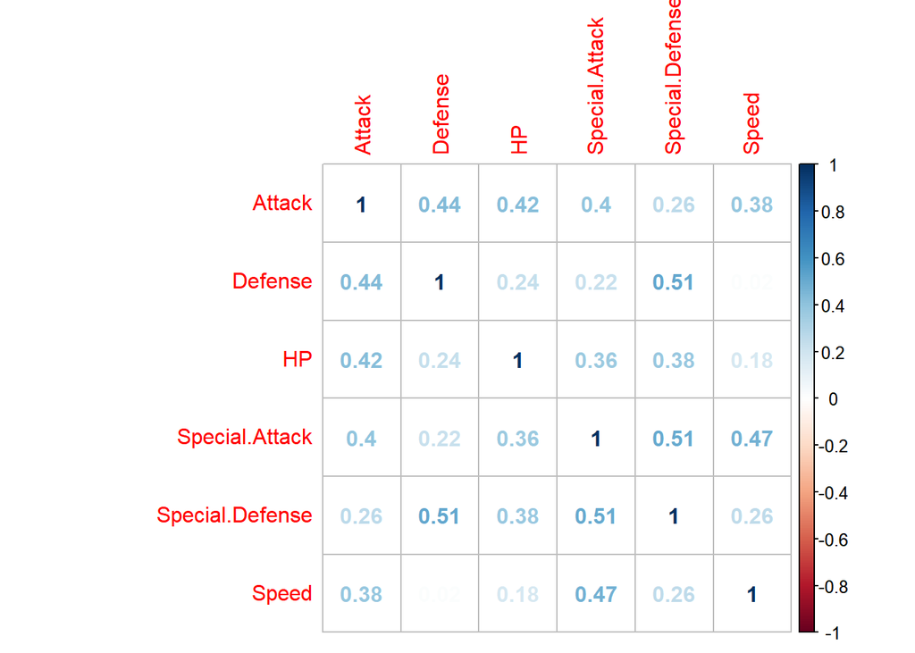

```r
corrplot(pokemonCorrelation, order ="alphabet", method = 'number')
```

MDS